# Medicines Regulation: Overview

Adam La Caze School of Pharmacy The University of Queensland

# Background

## Why regulate?

The provision of healthcare is tightly regulated. You (probably) want it that way—certainly society wants it that way. The principle purpose of regulation (healthcare or otherwise) is to keep the public **safe**.

## Nursing and Midwifery Practice and regulation

Being a health professional well means practicing in accordance with the law.

Practising outside of the law puts the *public* at risk.

If that is not a good enough reason; practising outside the law puts *you* at risk.

Risk of civil litigation

Risk of professional [censure](http://en.wikipedia.org/wiki/Censure): unprofessional conduct/professional misconduct (perhaps leading to removal of registration).

Risk of prosecution in the courts for breaches of the MPMR

## Law and medicines

Quite a lot of legislation is relevant to nursing and midwifery practice.

- [*Medicines and Poisons Act 2019*](https://www.legislation.qld.gov.au/view/html/asmade/act-2019-026)—the Act provides the basis for the more detailed regulations
- [*Medicines and Poisons (Medicines) Regulation 2021*](https://www.health.qld.gov.au/system-governance/licences/medicines-poisons/medicines-poisons-act)—provides the details regarding the “who”, “what” and “how” regulating medicines management
- *Standard for Uniform Scheduling for Medicines and Poisons* (referred to as: [SUSMP](http://www.tga.gov.au/industry/scheduling-poisons-standard.htm))—a national document that provides the medicines schedule for each drug
- [QH Departmental Standard: Monitored Medicines version 1](https://www.health.qld.gov.au/__data/assets/pdf_file/0029/1108937/ds-monitored-medicines.pdf)—a standard regarding monitored medicines and the responsibilities of health professionals prescribing, dispensing and administering monitored medicines

The nice thing about legislation is that it is written down.

# Aim

## Objectives (Overall)

1. Understand the purpose and contents of the MPMR in the context of nursing and midwifery practice
2. Be able to navigate the MPMR
3. Be able to determine how a medicine needs to be prescribed, dispensed and administered to be in accordance with the law.

## This section of the module…

We’ll focus on the first objective

> Understand the purpose and contents of the MPMR in the context of nursing and midwifery practice

We will start with the broader context.

## Key concepts

These are the key concepts you should take away from this section of the module:

1. The MPMR provides the regulations for prescribing, dispensing and other forms of medication supply in Queensland.
2. The SUSMP provides the scheduling for all medicines available in Australia. Key schedules for health professionals: S2, S3, S4 and S8. The higher the schedule the tighter the MPMR regulations for prescribing, dispensing and administering the medicine.
3. There is additional guidance for practice, including: professional standards and key medicine resources

## Medicines regulation: overview

An overview of medicines regulation

| Instrument | Acronym | Function |
| --- | --- | --- |
| Standard for Uniform Scheduling for Medicines and Poison | SUSMP | Provides scheduling for all medicines available in Australia |
| Medicines and Poisons (Medicines) Regulation 2021 | MPMR | Provides regulations for prescribing, dispensing and supply of medicines in Queensland |
| Pharmaceutical Benefits Scheme | PBS | The federal scheme that subsidizes medication costs |

# MPMR in context

## A process for administering medicines

The MPMR provides (among other things) the regulations for prescribing, dispensing and administering medicines in Queensland.

Here’s a schematic of some of the things that are important before a medicines is administered to supplied to a patient:

1. What schedule is the medicine?
2. Is the prescription legal?
3. Is the prescription therapeutically appropriate?
4. Has the right drug, dose, dose form been dispensed?
5. Is the label on the medicine correct and meet the legal requirements?
6. It is safe and legal to administer the drug to the person under your care?

## Step 1: Scheduling (SUSMP)

- Medicine scheduling is provided by the *Standard for the Uniform Scheduling of Medicines and Poisons* (SUSMP)
- Roughly speaking, the more dangerous the drug—due to toxicity or potential for abuse—the more restricted the scheduling.
- The regulations provided in the MPMR depend on the schedule of the medicine

## Key Schedules

Different terminology used for drug schedules. The SUSMP has schedule 1–9. S2–4 and S8 are the schedules that you most frequently come across.

| SUSMP | Synonyms | Examples |
| --- | --- | --- |
| S2,S3 | Over-the-counter drugs | Paracetamol |
| S4 | Prescription drug | Antibiotics |
| S8 | Dangerous drug/Controlled drug | Opioids |

## Steps 2, 5 and 6: MPMR

MPMR prescribes who is **authorised** to undertake specific activities (**dealings**) with medicines

## Steps 3 and 6: Key medicine references

Judging whether a prescription is therapeutically appropriate for an individual can be the most difficult (and important) step.

Responsibilities for assessing therapeutic appropriateness differs among the healthcare team and the roles that different professions are playing.

Prescribers (medical and non-medical prescribers such as nurse practitioners), dispensers (usually pharmacists) and those administering the medicine (often nurses and midwives) each have a role to play in ensuring quality use of medicines.

A number of medicines-specific resources can help inform this judgement:

1. [Australian Medicines Handbook](https://www-amh-net-au.ezproxy.library.uq.edu.au/online/view.php?page=index.php)
2. [MIMS Online](http://search.library.uq.edu.au/61UQ:61UQ_All:61UQ_ALMA61117031600003131)
3. [Therapeutic Guidelines](http://online.tg.org.au.ezproxy.library.uq.edu.au/ip/desktop/index.htm)

## Professional Standards

“Professional standards” are standards of practice that have been developed by your profession. The standards provide guidance for most aspects of professional practice.

Examples can be found on the [Nursing and Midwifery Board of Australia](http://www.nursingmidwiferyboard.gov.au/Codes-Guidelines-Statements/Professional-standards.aspx) website:

- Code of conduct for midwives
- Code of conduct for nurses
- Registered nurse standards for practice
- Midwifery competency standards
- Midwife standards for practice

## What professional standards *do*

Professional standards describe how nurses and midwives *should* practice.

The competency standards describe the *knowledge* and *skills* required to practice nursing and midwifery

The professional practice standards describe *how* nurses and midwives should provide good care; e.g. the systems and procedures they should put in place to ensure safe and effective care, including safe and effective use of medicines.

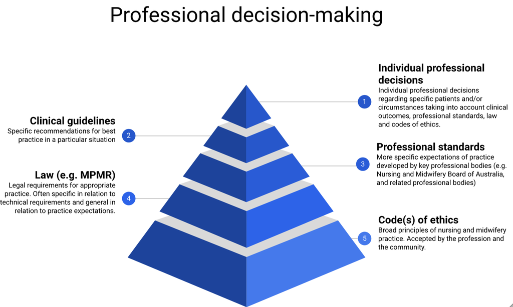

## Pharmaceutical Benefits Scheme

The [Pharmaceutical Benefits Scheme](http://www.pbs.gov.au/pbs/home) is the mechanism by which the Australian Government subsidises the costs of necessary medicines for the Australian public.

The PBS places requirements on prescriptions—if the prescription does not meet these requirements the prescription can’t be subsidised under the PBS.

State governments are responsible for the medicines supplied in hospital, the federal government through the PBS is responsible for medicines supplied privately (or on discharge from hospital).

## Summary

This section of the module has introduced the *Medicines and Poisons (Medicines) Regulation 2021* and *Schedule for the Uniform Scheduling of Medicines and Poisons (SUSMP)* and put these into a broader context of professional standards for practice.

Do the quiz! Then start the next section of the module.